**PRM Release MillFrame 4.1.0**

**Web Portal User Guide**

Confidential and Proprietary

© 2017 Milliman, Inc. All rights reserved.  
Milliman® is a trademark of Milliman, Inc.  
All other trademarks belong to their respective owners

This manual and its contents are the confidential property of Milliman, Inc. and are prepared for the exclusive use of Milliman, Inc. and its subscribing clients. Any distribution or reproduction, intentional or unintentional, of any materials contained herein without the express written permission of Milliman, Inc. is prohibited.

For additional information, please contact our technical support team by email: *prm.support@milliman.com*

**Introduction**

Milliman PRM Analytics is a predictive analytics solution capable of predicting any number of healthcare management risks. The primary predictive analytics are the Opportunity Prospective Scores.

Milliman PRM Analytics are backed by more than 65 years of experience in healthcare consulting, data analytics, operational analysis and problem solving. The solutions offered by this tool leverage a unique reporting structure and custom analytics that help meet coming healthcare challenges head on.

This user guide is designed to give users an understanding of the latest features of the PRM Project Management Console (PMC) and step by step instructions for using the system.

**Note: Please note that these instructions are ONLY meant for users who have been granted access**.

**Functionality is dictated by what was enabled for the role assigned to the user and the options enabled for the client. For illustration purposes, all of the functionality is enabled in the screen shots shown below.**

**Technical Support**

If you are having any technical difficulty with the product, please contact our technical support team by email: *prm.support@milliman.com*

*Note: For the purpose of this user guide, all data has been de-identified to protect patient’s personal health information (PHI) in accordance with the Health Insurance Portability and Accountability Act of 1996 (HIPAA).*

## PRM Project Management Console

## Overview

Millframe 4.1.0 consists of five modules, and Web Portal is one of those. The PRM Web Portal module allows the client users to view the reports for the group(s) they are associated with. The application also allows the Client User Administrators to launch Client User Administration Console application, and the Client Publishers to launch Client Publisher Console application.

## Definitions

**Group –** an arbitrary container used to associate **Users** to **Reports** (QVWs).

The PMC is used to manage **Projects** and **Reports** for **Groups**.

**Signature –** extra attributes attached to a QVW (**Report**) that identifies a specific **Group** the report may be associated with via the **Project Management Console**.

The goal of a **Signature** is to keep a **User** who is running the **Project Management Console** from accidentally putting a **Report** into the wrong **Group** and having PHI sent to **Users** in a different **Group** who shouldn’t have access to it.

**Analytics Pipeline** – Onboarding, translation/transformation, or processing code used to calculate value-added data and binding data onto a QVW (**Report**) that is signed (**Signature**) for a specific **Group**.

The **Analytics Pipeline** is the side that generates the **Reports.** The data is processed and turned into value-added fields which are bound onto a QlikView interface which results in a QVW (**Report**).

The **QVW** is then signed and that **Signature** is carried along with it and dictates certain things about that **Report** and provides security for the data, which flows from the **Analytics Pipeline** to the security framework of PRM.

## Signature Tool

1. The **Signature Tool** is a tool that allows the user to view how a Report is signed. Since this Test Report is already, we will use the tool to view the Signature.

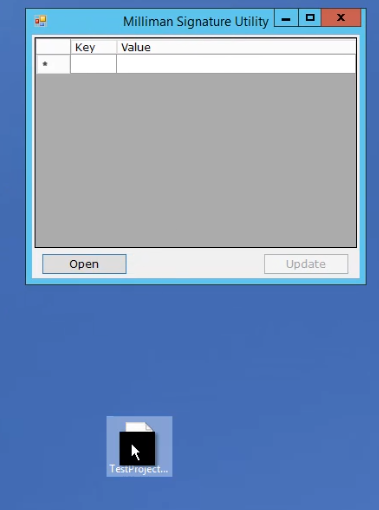

1. So we click to open the Signature Tool.

[figure not shown]

1. Next we click on Test Project

[figure not shown]

1. Next we look inside at the information contained in the **Signature**.

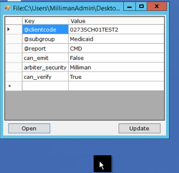

1. This is custom code, the same code used in the **Analytics Pipeline**. It has a command line interface, where you can call and update this information. When you look at a **Signature**, the security framework understands that when you have keys that begin with a @ sign, you should concatenate all these lines together. This is this case what you are trying to do is to create a **Group** code. This group is called 0273SCH01TEST2. This dictates the directory that this **Report** can go into. Let us look at some other keys.
- **can_emit**. This asks “Does this QlikView report contain all the extra scripts in the **QVW** that allows the security framework to determine hierarchical information inside report so it can do loop and reduce or it can reduce a view of the report down. The primary use of this key is to allow a **User** account to be associated with a sub-set of data in the **Report**. SO, if the value of can_emit is set to True, then we have the capability of allowing a **User** to be associated with a sub-set of date in the **Report**. Since the value here is set to False, it means that ALL the Users will always see ALL the data all the time.
- **ariber_security**. Since currently there is one security framework, we always set this to Milliman. If you had a client with multiple security frameworks, then those values would be added to the **Signature**.
- **can_verify**. This signifies that there is another script in the **QVW** that allows us to look at what is inside the QVW once it has been reduced. So, for example, if you come in and say, “User A can only see Providers B&C, the **can_verify** script says “Another association has been made, we’ve reduced the QVW down and now if I look back inside the QVW as part of the auditing process, I can verify that Providers B&C are still the only 2 providers that User A can see. Basically, it allows auditing of the QVW once it has been produced.

## Project Management Console

**NOTE: By default, the Project Management Console is run in Firefox, but for the purposes of this guide, we will be using Internet Explorer.**

[figure not shown]

1. First we log into the PMC.

[figure not shown]

1. Then we go into the folders which are set up a lot like File Explorer.

[figure not shown]

1. You drill down to a leaf node and eventually get to a **Project**. In this case our **Project** is **hciprj.**

[figure not shown]

1. There is information here in the **User Interface**. There is a **Refresh** button on top. You use this when importing new information into the **Project.**

[figure not shown]

1. You call also tell it to create a new **Directory**.

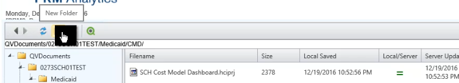

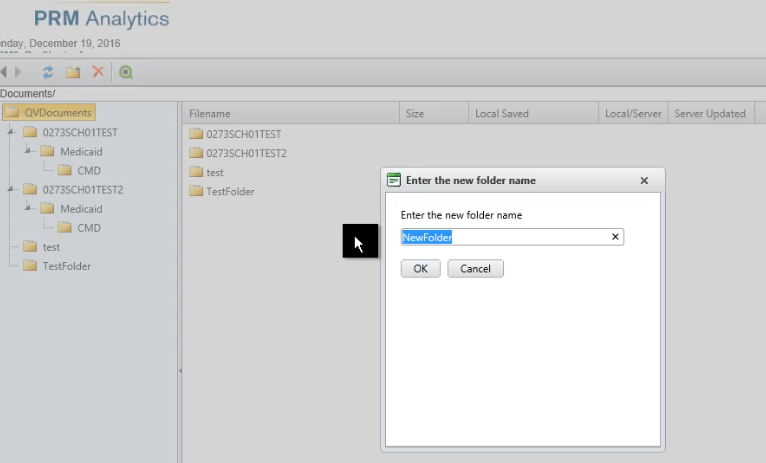

1. We will call this directory Test7.

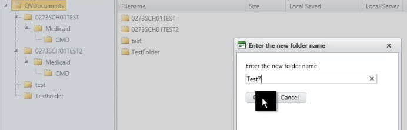

1. Once created, the Test7 folder appears.

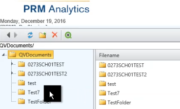

1. You can also use the red X to delete a folder. There are certain ramifications in deleting a folder which will be discussed at a later time.

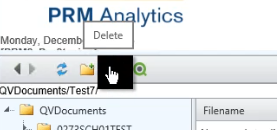

1. Last, you can click the green icon with the black center dot on the right to create a **Project** from a signed **QVW**. This is essentially the **Import** feature.

[figure not shown]

1. This is the way we bring all of the QVWs into the security framework for the first time. After that we do updates on a monthly or bi-monthly basis.
2. Before exploring the Import feature, let’s go back to the folder tree.

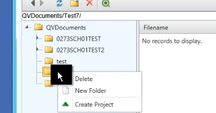

1. Once you go to the folder you have created and right-click, you are given 3 options:
- Delete (like the option above)
- Create a New Folder and
- Create a Project
1. The purpose of this option is to allow the **User** to create a new **Project** inside this folder. So we click on folder Test7 and **Create Project.**

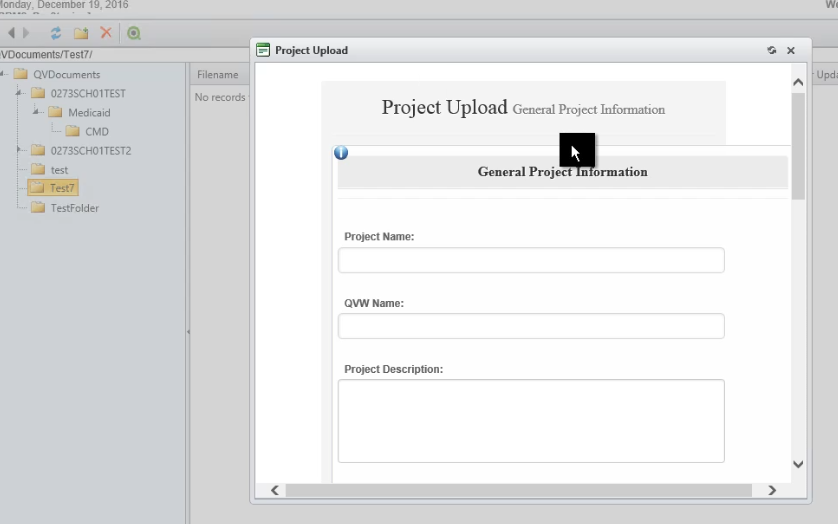

1. A dialogue box appears with a number of fields that the User can fill out.

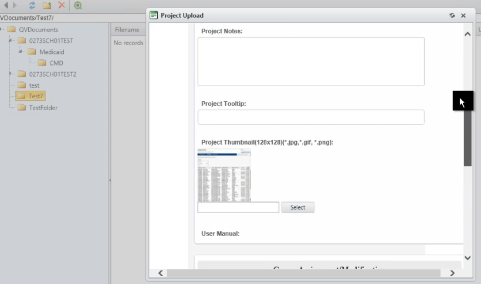

1. The end result of filling out the dialogue box is the creation of an **nciprj** file being saved in this directory named Test7.

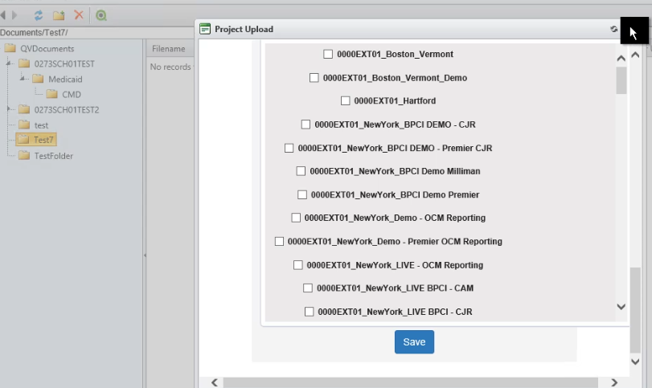

1. The way this is typically done is using the previously mentioned **Import**.

[figure not shown]

1. The **Create Folder** and **Create a Project** method was the original way the system was set up. As the system evolved, it was decided that from a security standpoint it would be better for the files to be created from projects with existing **security codes**.

[figure not shown]

1. So essentially the **nciprj** **Project** file is like an envelope that contains all the report and **security code** information listed in the **Signature** and is linked to a specific **Group** by using a specific **Client Code** and the directory structure.

[figure not shown]

1. When this information is pushed to the Production machine, all this information, it makes sure that the Test **QVW** (report) with this specific **Signature** can only be sent to the specific **Group** 0273SC01TEST2 .
2. The **Signature** also dictates where the **Report** sits in the directory structure.
3. Only **Users** associated with **Group** 0273SC01TEST2 will be able to see this **Report**.
4. The remaining values in the Signature, **can_emit** and **can_verify** describe other capabilities the security framework has.

## Additional Functions of the Project Management Console

1. Right-clicking on the Project folder reveals an additional **Options** menu.

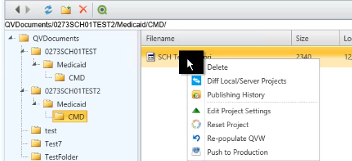

1. Delete would remove the **Project** from the **Group**. The **Group** and associated **Users** would remain intact but with no associated **Report**.

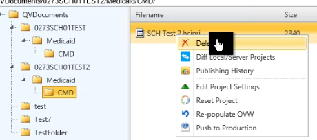

1. Whoever is running the **PMC** isn’t running it on the Production machine. The Production machine has a copy from previous posts. Clicking on **Diff Local/ Server Projects** allows **Users** to see if someone has come in locally on this machine since the last time and updated this project.

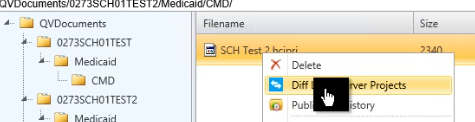

1. In this example, the value for Local/Server is equal.

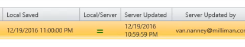

1. Clicking **Diff Local/ Server Projects** for the details, we see that the values for each option are indeed equal.

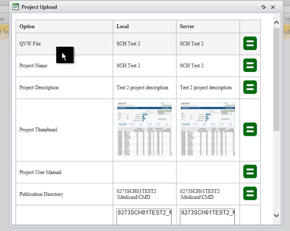

1. So scrolling down and checking all the values, you know that the local version and the copy on the server are both the same.
2. The next menu item, **Publishing History** provides a record of each time the **Project** was modified.

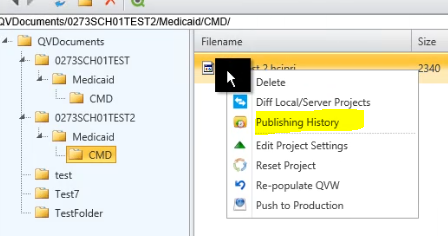

1. Opening up the dialogue box reveals the last time the **Project** was published and who published it.

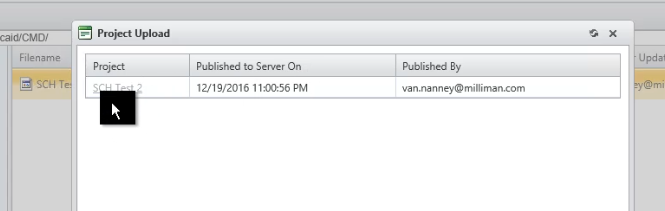

1. This was just the initial version. As people publish more versions, those are added to the list and we can go back and look at who is publishing and what those versions look like.
2. The next item, **Edit Project Settings** is the same as when we clicked on the folder tree on the left.

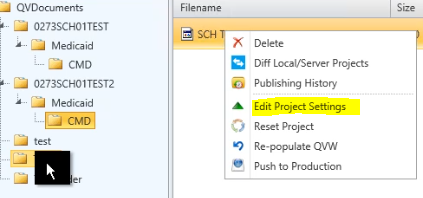

1. So when we click on **Edit Project Settings** the dialogue box pops up

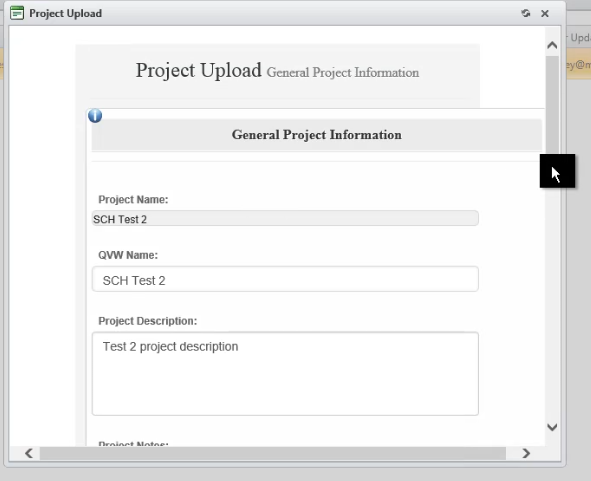

1. The **Project** name is the same as the original **hciprj name** and the **QVW** is name of the **Report** itself.